# Continuous Biomarker Evaluation

- Show All Code
- Hide All Code
- View Source

Comparing STEPP, MFPI, and Spline Cox (cox_cs_fit) on GBSG and Simulated Data

Author

ForestSearch Package Documentation

Published

March 19, 2026

```r
library(survival)
library(splines)
library(mfp)
library(forestsearch)   # provides cox_cs_fit()
library(ggplot2)
library(patchwork)
library(scales)         # percent_format() for coverage axis
library(dplyr)
library(doFuture)       # %dofuture% operator for parallel simulation
library(foreach)        # foreach() used by run_ccsf_eval() / run_stepp_eval()
```

**NoteRelationship to ForestSearch**

`cox_cs_fit()` is the primary continuous-biomarker evaluation tool in `forestsearch`. It produces a log-HR profile over the biomarker range and directly supports optimal cut-point identification for subgroup definition. STEPP and MFPI serve as **complementary external validation tools** making different modelling assumptions — convergent findings across all three methods strengthen confidence in a predictive biomarker claim.

## 1 Overview

A continuously-measured biomarker may **modify a treatment effect** — patients at different parts of the biomarker range may respond differently to therapy. Three methods address this question for survival endpoints:

| Method | Core Idea | Functional Form | R Implementation |
| --- | --- | --- | --- |
| **`cox_cs_fit()`** | `forestsearch` wrapper: natural-spline interaction Cox model; returns profile + CIs directly | Smooth, flexible | `forestsearch` |
| **Manual Spline Cox** | Same model as above, exposed step-by-step for transparency | Smooth, flexible | `survival` + `splines` |
| **MFPI** | FP functions fit separately per arm; difference is the treatment-effect curve | Data-driven low-degree polynomial | `mfp` (CRAN) |
| **STEPP** | Model-free log-HR estimates in overlapping sliding windows | None (nonparametric) | `stepp` (CRAN) |

This vignette applies all three to (1) the **GBSG dataset** examining whether progesterone receptor (PGR) predicts hormonal therapy benefit, and (2) four **synthetic simulation scenarios** with known ground-truth interaction functions, including a formal simulation evaluation of SE calibration, coverage, and CI width for both `cox_cs_fit()` and STEPP.

## 2 GBSG Dataset Analysis

### 2.1 Data Preparation

The German Breast Cancer Study Group (GBSG) trial randomised 686 node-positive breast cancer patients to adjuvant **hormonal therapy** (`hormon = 1`) versus **control** (`hormon = 0`). The endpoint is recurrence-free survival (`rfstime`, days; `status` = 1 for recurrence/death).

We examine **progesterone receptor** (`pgr`, fmol) as a candidate predictive biomarker. Because `pgr` is strongly right-skewed (range 0–2380 fmol), all analyses use the $\log(\text{pgr}+1)$ scale throughout. Time is converted from days to years.

```r
data("gbsg", package = "survival")

gbsg <- gbsg |>
  mutate(
    rfstime_yr = rfstime / 365.25,
    log_pgr    = log(pgr + 1),
    treat      = hormon
  )

cat(sprintf(
  "N = %d  |  Events = %d (%.1f%%)  |  Hormonal arm n = %d  |  Control n = %d\n",
  nrow(gbsg), sum(gbsg$status), 100 * mean(gbsg$status),
  sum(gbsg$treat == 1), sum(gbsg$treat == 0)
))
```

```
N = 686  |  Events = 299 (43.6%)  |  Hormonal arm n = 246  |  Control n = 440
```

```r
fit_itt    <- coxph(Surv(rfstime_yr, status) ~ treat, data = gbsg)
hr_itt     <- exp(coef(fit_itt)["treat"])
ci_itt     <- exp(confint(fit_itt)["treat", ])
loghr_itt  <- coef(fit_itt)["treat"]

cat(sprintf(
  "Overall HR (hormonal Rx vs control): %.3f  (95%% CI: %.3f – %.3f)\n",
  hr_itt, ci_itt[1], ci_itt[2]
))
```

```
Overall HR (hormonal Rx vs control): 0.695  (95% CI: 0.544 – 0.888)
```

### 2.2 Biomarker Distribution

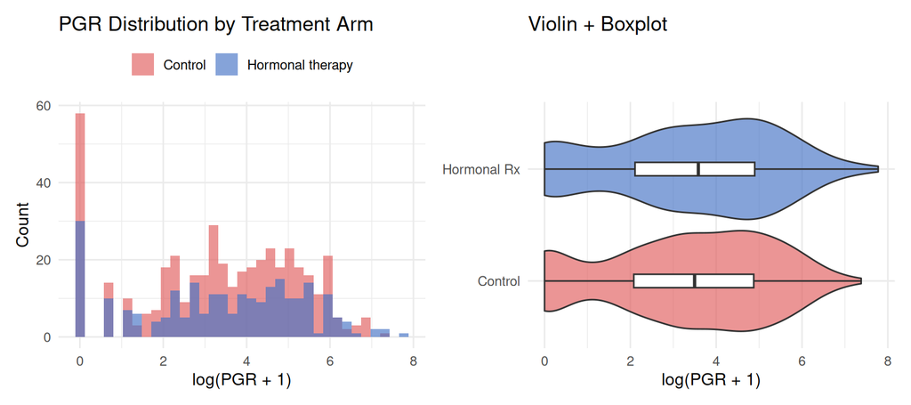

Distribution of log(PGR+1) by treatment arm. Balance across arms supports biomarker evaluation as an effect modifier.

```r
p_hist <- ggplot(gbsg, aes(x = log_pgr, fill = factor(treat))) +
  geom_histogram(bins = 35, alpha = 0.65, position = "identity") +
  scale_fill_manual(values  = c("#E05C5C", "#4472C4"),
                    labels  = c("Control", "Hormonal therapy")) +
  labs(x = "log(PGR + 1)", y = "Count", fill = NULL,
       title = "PGR Distribution by Treatment Arm") +
  theme_minimal(base_size = 12) +
  theme(legend.position = "top")

p_box <- ggplot(
  gbsg,
  aes(x = log_pgr,
      y = factor(treat, labels = c("Control", "Hormonal Rx")),
      fill = factor(treat))
) +
  geom_violin(alpha = 0.65, show.legend = FALSE) +
  geom_boxplot(width = 0.12, outlier.size = 0.7,
               fill = "white", show.legend = FALSE) +
  scale_fill_manual(values = c("#E05C5C", "#4472C4")) +
  labs(x = "log(PGR + 1)", y = NULL, title = "Violin + Boxplot") +
  theme_minimal(base_size = 12)

p_hist + p_box + plot_layout(ncol = 2)
```

### 2.3 Shared Biomarker Grid

```r
# All three methods share this prediction grid (5th–95th percentile)
z_grid <- seq(
  quantile(gbsg$log_pgr, 0.05),
  quantile(gbsg$log_pgr, 0.95),
  length.out = 200L
)
nd_grid <- data.frame(log_pgr = z_grid)
```

### 2.4 Method 1: `cox_cs_fit()` from `forestsearch`

The spline Cox model underlying `cox_cs_fit()` is:

$$h(t \mid Z, A) = h_0(t)\,\exp\!\bigl(\beta_0 A + f(Z) + g(Z) \cdot A\bigr)$$

where $Z = \log(\text{pgr}+1)$, $A$ = treatment, $f(Z)$ is a prognostic natural spline and $g(Z)$ a treatment-interaction natural spline. The log-HR profile is $\hat\beta(Z) = \hat\beta_0 + \hat g(Z)$ with pointwise CIs from the **delta method** using the full model $\Sigma$.

```r
gbsg_fs <- gbsg |>
  rename(os_time  = rfstime_yr,
         os_event = status) |>
  mutate(bm = log_pgr)

fit_ccsf <- cox_cs_fit(
  df         = gbsg_fs,
  tte_name   = "os_time",
  event_name = "os_event",
  treat_name = "treat",
  z_name     = "bm",
  spline_df  = sim_spline_df,
  z_by       = 0.05,
  z_quantile = 0.95,
  alpha      = sim_alpha,
  show_plot  = FALSE,
  verbose    = FALSE
)

cat(sprintf("cox_cs_fit: %d profile points from %.3f to %.3f\n",
            length(fit_ccsf$z_profile),
            min(fit_ccsf$z_profile), max(fit_ccsf$z_profile)))
```

```
cox_cs_fit: 121 profile points from 0.000 to 6.000
```

```r
cat(sprintf("log-HR range: %.3f to %.3f\n",
            min(fit_ccsf$loghr_est), max(fit_ccsf$loghr_est)))
```

```
log-HR range: -1.085 to 0.061
```

```r
df_ccsf <- data.frame(
  z      = fit_ccsf$z_profile,
  pgr    = exp(fit_ccsf$z_profile) - 1,
  loghr  = fit_ccsf$loghr_est,
  lo     = fit_ccsf$loghr_lower,
  hi     = fit_ccsf$loghr_upper,
  method = "cox_cs_fit (forestsearch)"
)
```

### 2.5 Method 1b: Manual Spline Cox (for transparency)

```r
spline_df <- sim_spline_df

fit_spline <- coxph(
  Surv(rfstime_yr, status) ~
    treat + ns(log_pgr, df = spline_df) + ns(log_pgr, df = spline_df):treat,
  data = gbsg
)

fit_main <- coxph(
  Surv(rfstime_yr, status) ~ treat + ns(log_pgr, df = spline_df),
  data = gbsg
)
lrt <- anova(fit_main, fit_spline)
cat(sprintf(
  "LRT for treat x ns(log_pgr): Chi-sq = %.2f, df = %d, p = %.4f\n",
  lrt[2L, "Chisq"], lrt[2L, "Df"], lrt[2L, "Pr(>|Chi|)"]
))
```

```
LRT for treat x ns(log_pgr): Chi-sq = 6.43, df = 3, p = 0.0924
```

```r
nd1 <- data.frame(log_pgr = z_grid, treat = 1)
nd0 <- data.frame(log_pgr = z_grid, treat = 0)

X1    <- model.matrix(fit_spline, data = nd1)
X0    <- model.matrix(fit_spline, data = nd0)
Xdiff <- X1 - X0

loghr_spline <- as.numeric(Xdiff %*% coef(fit_spline))
se_spline    <- sqrt(diag(Xdiff %*% vcov(fit_spline) %*% t(Xdiff)))

df_spline <- data.frame(
  z      = z_grid,
  pgr    = exp(z_grid) - 1,
  loghr  = loghr_spline,
  lo     = loghr_spline - 1.96 * se_spline,
  hi     = loghr_spline + 1.96 * se_spline,
  method = "Manual Spline Cox"
)

shared_z <- intersect(round(df_ccsf$z, 3), round(df_spline$z, 3))
if (length(shared_z) > 0) {
  idx_c <- match(round(shared_z[1], 3), round(df_ccsf$z, 3))
  idx_m <- match(round(shared_z[1], 3), round(df_spline$z, 3))
  cat(sprintf(
    "Agreement check at Z = %.3f: cox_cs_fit = %.4f, manual = %.4f (diff = %.2e)\n",
    shared_z[1],
    df_ccsf$loghr[idx_c],
    df_spline$loghr[idx_m],
    abs(df_ccsf$loghr[idx_c] - df_spline$loghr[idx_m])
  ))
}
```

```
Agreement check at Z = 0.000: cox_cs_fit = 0.0606, manual = 0.0606 (diff = 0.00e+00)
```

### 2.6 Method 2: MFPI

```r
fit_mfp0 <- mfp(Surv(rfstime_yr, status) ~ fp(log_pgr, df = 4),
                data   = filter(gbsg, treat == 0),
                family = cox, verbose = FALSE)

fit_mfp1 <- mfp(Surv(rfstime_yr, status) ~ fp(log_pgr, df = 4),
                data   = filter(gbsg, treat == 1),
                family = cox, verbose = FALSE)

cat("FP powers selected — Control:", fit_mfp0$powers[, "power1"],
    " | Hormonal Rx:", fit_mfp1$powers[, "power1"], "\n")
```

```
FP powers selected — Control: 1  | Hormonal Rx: 1
```

```r
lp0_mfp <- predict(fit_mfp0, newdata = nd_grid, type = "lp")
lp1_mfp <- predict(fit_mfp1, newdata = nd_grid, type = "lp")

raw_mfp   <- lp1_mfp - lp0_mfp
loghr_mfp <- raw_mfp - mean(raw_mfp) + loghr_itt

set.seed(2024L)
n_boot <- sim_n_boot_mfpi
boot_mat <- matrix(NA_real_, nrow = n_boot, ncol = length(z_grid))

for (b in seq_len(n_boot)) {
  idx  <- sample(nrow(gbsg), replace = TRUE)
  bdat <- gbsg[idx, ]

  f0b <- tryCatch(
    mfp(Surv(rfstime_yr, status) ~ fp(log_pgr, df = 4),
        data = filter(bdat, treat == 0), family = cox, verbose = FALSE),
    error = function(e) NULL
  )
  f1b <- tryCatch(
    mfp(Surv(rfstime_yr, status) ~ fp(log_pgr, df = 4),
        data = filter(bdat, treat == 1), family = cox, verbose = FALSE),
    error = function(e) NULL
  )
  if (is.null(f0b) || is.null(f1b)) next

  lp0b <- tryCatch(predict(f0b, newdata = nd_grid, type = "lp"),
                   error = function(e) NULL)
  lp1b <- tryCatch(predict(f1b, newdata = nd_grid, type = "lp"),
                   error = function(e) NULL)
  if (is.null(lp0b) || is.null(lp1b)) next

  raw_b         <- lp1b - lp0b
  boot_mat[b, ] <- raw_b - mean(raw_b) + loghr_itt
}

n_valid <- sum(complete.cases(boot_mat))
cat(sprintf("Bootstrap: %d/%d valid resamples\n", n_valid, n_boot))
```

```
Bootstrap: 200/200 valid resamples
```

```r
df_mfpi <- data.frame(
  z      = z_grid,
  pgr    = exp(z_grid) - 1,
  loghr  = loghr_mfp,
  lo     = apply(boot_mat, 2, quantile, probs = 0.025, na.rm = TRUE),
  hi     = apply(boot_mat, 2, quantile, probs = 0.975, na.rm = TRUE),
  method = "MFPI"
)
```

### 2.7 Method 3: STEPP

STEPP (Bonetti & Gelber, 2000) partitions the biomarker range into overlapping **sliding windows** and estimates the treatment effect within each window. No functional form is assumed — the method is a purely graphical diagnostic.

Two window parameters govern resolution:

- **`patspop`** ($r_2$): approximate patients per window (≥ 80–100 recommended)
- **`minpatspop`** ($r_1$): maximum patients shared between consecutive windows

**Note**

**Install `stepp`:** `install.packages("stepp")`. The package has compiled dependencies (`lme4`, `car`, `Rcpp`); binary installation is fastest on Windows and macOS. The permutation test (`nperm > 0`) provides formal inference for treatment-effect heterogeneity across the biomarker range.

**Sign convention:** `stmodelKM` computes `logHR = -(O - E)/Var` for `trts[2]` relative to `trts[1]`. To obtain *log(HR treated vs control)* matching the Cox convention (negative = benefit), set `trts = c(1, 0)` so that `trts[1]` = treated arm and `trts[2]` = control arm.

**Note on package placement:** `stepp_fit()` and `stepp_windows()` are defined inline here for vignette self-sufficiency. In a future release they should be exported from `forestsearch` so that parallel workers spawned by `run_stepp_eval()` can access them without re-sourcing.

```r
# =============================================================================
# stepp_windows() — Cox-based sliding window fallback (no external dependencies)
# =============================================================================
stepp_windows <- function(df, bm_var, tte_var, event_var, treat_var,
                          patspop    = sim_patspop,
                          minpatspop = sim_minpatspop,
                          conf_level = 1 - sim_alpha) {
  stopifnot(patspop > minpatspop)
  z_crit <- qnorm(1 - (1 - conf_level) / 2)
  df_ord <- df[order(df[[bm_var]]), ]
  n      <- nrow(df_ord)
  step   <- patspop - minpatspop
  starts <- seq(1L, n - patspop + 1L, by = step)

  rows <- lapply(starts, function(i) {
    sub <- df_ord[seq(i, i + patspop - 1L), ]
    fit <- tryCatch(
      coxph(
        as.formula(sprintf("Surv(%s,%s) ~ %s", tte_var, event_var, treat_var)),
        data = sub
      ),
      error = function(e) NULL
    )
    if (is.null(fit)) return(NULL)
    b  <- coef(fit)[[treat_var]]
    se <- sqrt(vcov(fit)[treat_var, treat_var])
    data.frame(mid_bm   = median(sub[[bm_var]]),
               n_sub    = patspop,
               n_events = sum(sub[[event_var]]),
               loghr    = b,
               se_loghr = se,
               lo       = b - z_crit * se,
               hi       = b + z_crit * se,
               method   = "STEPP-Cox")
  })
  do.call(rbind, Filter(Negate(is.null), rows))
}


# =============================================================================
# stepp_fit() — unified STEPP wrapper analogous to cox_cs_fit()
# =============================================================================
stepp_fit <- function(df,
                      tte_name    = "os_time",
                      event_name  = "os_event",
                      treat_name  = "treat",
                      bm_name     = "bm",
                      patspop     = sim_patspop,
                      minpatspop  = sim_minpatspop,
                      nperm       = 0L,
                      time_point  = sim_time_point,
                      conf_level  = 1 - sim_alpha,
                      verbose     = TRUE) {

  stopifnot(
    is.data.frame(df),
    all(c(tte_name, event_name, treat_name, bm_name) %in% names(df)),
    patspop > minpatspop,
    conf_level > 0, conf_level < 1
  )

  z_crit <- qnorm(1 - (1 - conf_level) / 2)

  # ── Branch: stepp CRAN package ─────────────────────────────────────────────
  if (requireNamespace("stepp", quietly = TRUE)) {
    suppressPackageStartupMessages(library(stepp))
    if (verbose) message("stepp_fit: using stepp CRAN package (log-rank estimator)")

    swin <- new("stwin", type = "sliding",
                r1 = minpatspop, r2 = patspop)
    subp <- new("stsubpop")
    subp <- generate(subp, win = swin, covariate = df[[bm_name]])

    # trts = c(treated_code, control_code): logHR = treated vs control
    smod <- new("stmodelKM",
                coltrt    = df[[treat_name]],
                survTime  = df[[tte_name]],
                censor    = df[[event_name]],
                trts      = c(1, 0),
                timePoint = time_point)

    res  <- new("steppes")
    res  <- estimate(res, subp, smod)

    if (nperm > 0L) {
      res <- test(res, nperm = as.integer(nperm), showstatus = FALSE)
      tr  <- res@testresults$Res[[1]]
      pv_hr   <- tr$HRpvalue
      pv_km   <- tr$pvalue
      pv_chi2 <- tr$chi2pvalue
    } else {
      pv_hr <- pv_km <- pv_chi2 <- NA_real_
    }

    ratios      <- res@effect$Ratios[[1]]
    bm_profile  <- res@subpop@medianz
    loghr_est   <- ratios$logHR
    se_loghr    <- ratios$logHRSE
    overall_lhr <- ratios$ologHR
    overall_se  <- ratios$ologHRSE
    raw_stepp   <- res
    method_used <- "stepp_cran"

  # ── Branch: fallback Cox-based estimator ───────────────────────────────────
  } else {
    if (verbose) message("stepp_fit: stepp package not available — using Cox fallback")

    fb <- stepp_windows(df,
                        bm_var     = bm_name,
                        tte_var    = tte_name,
                        event_var  = event_name,
                        treat_var  = treat_name,
                        patspop    = patspop,
                        minpatspop = minpatspop,
                        conf_level = conf_level)

    bm_profile  <- fb$mid_bm
    loghr_est   <- fb$loghr
    se_loghr    <- fb$se_loghr
    overall_lhr <- overall_se <- NA_real_
    pv_hr <- pv_km <- pv_chi2 <- NA_real_
    raw_stepp   <- NULL
    method_used <- "stepp_windows_cox"
  }

  loghr_lower <- loghr_est - z_crit * se_loghr
  loghr_upper <- loghr_est + z_crit * se_loghr

  result <- list(
    bm_profile    = bm_profile,
    loghr_est     = loghr_est,
    se_loghr      = se_loghr,
    loghr_lower   = loghr_lower,
    loghr_upper   = loghr_upper,
    n_windows     = length(bm_profile),
    patspop       = patspop,
    minpatspop    = minpatspop,
    step_size     = patspop - minpatspop,
    overall_loghr = overall_lhr,
    overall_se    = overall_se,
    pvalue_hr     = pv_hr,
    pvalue_km     = pv_km,
    pvalue_chi2   = pv_chi2,
    conf_level    = conf_level,
    nperm         = nperm,
    method_used   = method_used,
    raw_stepp     = raw_stepp,
    bm_name       = bm_name,
    tte_name      = tte_name,
    event_name    = event_name,
    treat_name    = treat_name
  )
  class(result) <- c("stepp_fit", "list")

  if (verbose) {
    cat(sprintf(
      "stepp_fit [%s]: %d windows | r2 (patspop) = %d | r1 (minpatspop) = %d | step = %d\n",
      method_used, result$n_windows, patspop, minpatspop, result$step_size
    ))
    cat(sprintf("  log-HR range: %.3f to %.3f\n",
                min(loghr_est, na.rm = TRUE), max(loghr_est, na.rm = TRUE)))
    if (!is.na(pv_hr))
      cat(sprintf(
        "  Permutation p-values (nperm=%d): HR (primary) = %.4f | KM-sup = %.4f | KM-chi2 = %.4f\n",
        nperm, pv_hr, pv_km, pv_chi2
      ))
  }

  invisible(result)
}
```

```r
fit_stepp_gbsg <- stepp_fit(
  df         = gbsg,
  tte_name   = "rfstime_yr",
  event_name = "status",
  treat_name = "treat",
  bm_name    = "log_pgr",
  patspop    = sim_patspop,
  minpatspop = sim_minpatspop,
  nperm      = sim_nperm_gbsg,
  time_point = sim_time_point,
  conf_level = 1 - sim_alpha
)
```

```
stepp_fit [stepp_cran]: 7 windows | r2 (patspop) = 150 | r1 (minpatspop) = 50 | step = 100
  log-HR range: -0.901 to -0.009
  Permutation p-values (nperm=999): HR (primary) = 0.0741 | KM-sup = 0.6937 | KM-chi2 = 0.7578
```

```r
df_stepp_gbsg <- data.frame(
  mid_bm = fit_stepp_gbsg$bm_profile,
  loghr  = fit_stepp_gbsg$loghr_est,
  lo     = fit_stepp_gbsg$loghr_lower,
  hi     = fit_stepp_gbsg$loghr_upper,
  method = "STEPP"
)
```

### 2.8 STEPP CRAN vs Cox Fallback: Comparison on GBSG

| Estimator | Within-window log-HR formula |
| --- | --- |
| **CRAN** (`stepp_cran`) | $\hat\beta_{\text{LR}}(w) = -(O_{\text{ctrl}} - E_{\text{ctrl}})\;/\;\text{Var}$ (Schoenfeld) |
| **Fallback** (`stepp_windows_cox`) | $\hat\beta_{\text{Cox}}(w)$ from `coxph()` |

The two are asymptotically equivalent but **can diverge in windows with sparse events or large treatment effects** because the Schoenfeld approximation linearises around zero effect.

```r
fit_stepp_cox <- stepp_windows(
  df         = gbsg,
  bm_var     = "log_pgr",
  tte_var    = "rfstime_yr",
  event_var  = "status",
  treat_var  = "treat",
  patspop    = sim_patspop,
  minpatspop = sim_minpatspop,
  conf_level = 1 - sim_alpha
)
```

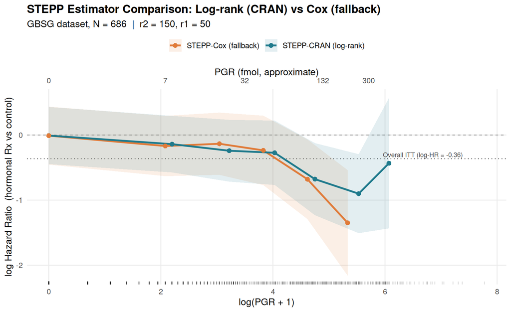

STEPP CRAN (log-rank Schoenfeld, teal) vs Cox fallback (orange) on GBSG. Differences widen at high PGR where events are sparse and the treatment effect is large.

```r
col_comp <- c("STEPP-CRAN (log-rank)" = "#1F7A8C", "STEPP-Cox (fallback)" = "#E07B39")

df_cran_comp <- data.frame(
  mid_bm = fit_stepp_gbsg$bm_profile,
  loghr  = fit_stepp_gbsg$loghr_est,
  lo     = fit_stepp_gbsg$loghr_lower,
  hi     = fit_stepp_gbsg$loghr_upper,
  method = "STEPP-CRAN (log-rank)"
)
df_cox_comp <- data.frame(
  mid_bm = fit_stepp_cox$mid_bm,
  loghr  = fit_stepp_cox$loghr,
  lo     = fit_stepp_cox$lo,
  hi     = fit_stepp_cox$hi,
  method = "STEPP-Cox (fallback)"
)
df_comp_all <- bind_rows(df_cran_comp, df_cox_comp)

ggplot(df_comp_all, aes(x = mid_bm, y = loghr, colour = method, fill = method)) +
  geom_hline(yintercept = 0,         linetype = "dashed", colour = "grey55", linewidth = 0.4) +
  geom_hline(yintercept = loghr_itt, linetype = "dotted", colour = "grey35", linewidth = 0.5) +
  geom_ribbon(aes(ymin = lo, ymax = hi), alpha = 0.12, colour = NA) +
  geom_line(linewidth = 1.1) +
  geom_point(size = 2.5, shape = 16) +
  annotate("text",
           x     = max(gbsg$log_pgr, na.rm = TRUE) * 0.95,
           y     = loghr_itt + 0.06,
           label = sprintf("Overall ITT (log-HR = %.2f)", loghr_itt),
           hjust = 1, size = 2.9, colour = "grey30") +
  geom_rug(data = gbsg, aes(x = log_pgr), inherit.aes = FALSE,
           alpha = 0.12, sides = "b", length = unit(0.015, "npc")) +
  scale_colour_manual(values = col_comp, name = NULL) +
  scale_fill_manual(values = col_comp, name = NULL) +
  scale_x_continuous(
    name = "log(PGR + 1)",
    sec.axis = sec_axis(~ exp(.) - 1,
                        name   = "PGR (fmol, approximate)",
                        breaks = c(0, 7, 32, 132, 300),
                        labels = c(0, 7, 32, 132, 300))
  ) +
  labs(y        = "log Hazard Ratio  (hormonal Rx vs control)",
       title    = "STEPP Estimator Comparison: Log-rank (CRAN) vs Cox (fallback)",
       subtitle = sprintf("GBSG dataset, N = 686  |  r2 = %d, r1 = %d", sim_patspop, sim_minpatspop)) +
  theme_minimal(base_size = 12) +
  theme(legend.position  = "top",
        panel.grid.minor = element_blank(),
        plot.title       = element_text(face = "bold"))
```

```r
matched <- lapply(seq_along(df_cran_comp$mid_bm), function(i) {
  z_c <- df_cran_comp$mid_bm[i]
  j   <- which.min(abs(df_cox_comp$mid_bm - z_c))
  data.frame(
    `Window median`       = round(z_c, 3),
    `CRAN log-HR`         = round(df_cran_comp$loghr[i], 3),
    `CRAN SE`             = round((df_cran_comp$hi[i] - df_cran_comp$lo[i]) / (2 * 1.96), 3),
    `Cox log-HR`          = round(df_cox_comp$loghr[j], 3),
    `Cox SE`              = round((df_cox_comp$hi[j] - df_cox_comp$lo[j]) / (2 * 1.96), 3),
    `Diff (CRAN - Cox)`   = round(df_cran_comp$loghr[i] - df_cox_comp$loghr[j], 3),
    `Events (Cox window)` = fit_stepp_cox$n_events[j],
    check.names = FALSE
  )
})
knitr::kable(do.call(rbind, matched), align = "rrrrrrr")
```

Window-level comparison of STEPP CRAN vs Cox fallback. |Diff| tends to increase with the magnitude of the effect and with decreasing event counts.

| Window median | CRAN log-HR | CRAN SE | Cox log-HR | Cox SE | Diff (CRAN - Cox) | Events (Cox window) |
| --- | --- | --- | --- | --- | --- | --- |
| 0.00 | -0.009 | 0.224 | -0.010 | 0.227 | 0.002 | 85 |
| 2.20 | -0.140 | 0.222 | -0.169 | 0.236 | 0.029 | 80 |
| 3.22 | -0.242 | 0.242 | -0.134 | 0.244 | -0.107 | 72 |
| 4.03 | -0.273 | 0.252 | -0.236 | 0.272 | -0.037 | 62 |
| 4.75 | -0.678 | 0.283 | -0.679 | 0.312 | 0.001 | 53 |
| 5.53 | -0.901 | 0.310 | -1.349 | 0.414 | 0.448 | 44 |
| 6.07 | -0.434 | 0.511 | -1.349 | 0.414 | 0.915 | 44 |

**NoteInterpreting the three permutation p-values**

`stepp_fit()` reports three distinct permutation p-values when `nperm > 0`:

| Slot | Null hypothesis tested | Recommended use |
| --- | --- | --- |
| `pvalue_hr` | Window log-HRs no more variable than chance | **Primary** for a log-HR treatment-effect profile |
| `pvalue_km` | Supremum of KM survival differences across windows | Secondary; sensitive to `time_point` |
| `pvalue_chi2` | Chi-squared statistic on KM differences | Secondary; same caveat |

For a continuous-biomarker subgroup analysis the **`pvalue_hr`** test is most directly interpretable. With 7 windows and N = 686, all three tests have limited power; `pvalue_hr` is the one to report alongside the profile plot.

### 2.9 Combined Results: GBSG

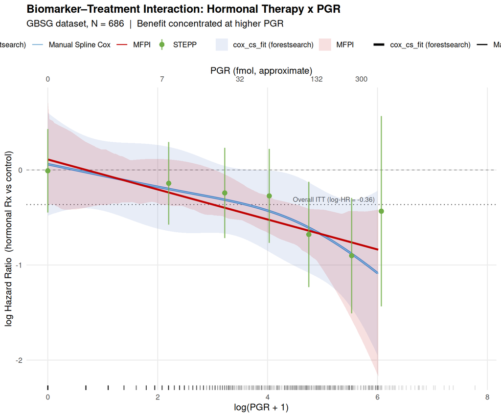

Treatment-effect (log-HR) profile for hormonal therapy vs control as a function of log(PGR+1). All four methods agree that benefit is concentrated at higher PGR values.

```r
col_map <- c(
  "cox_cs_fit (forestsearch)" = "#4472C4",
  "Manual Spline Cox"         = "#7BAFD4",
  "MFPI"                      = "#C00000",
  "STEPP"                     = "#70AD47"
)
lwd_map <- c(
  "cox_cs_fit (forestsearch)" = 1.4,
  "Manual Spline Cox"         = 0.7,
  "MFPI"                      = 1.2,
  "STEPP"                     = 1.0
)
pgr_ticks <- c(0, 7, 32, 132, 300)
df_ribbon  <- bind_rows(df_ccsf, df_spline, df_mfpi)

ggplot() +
  geom_hline(yintercept = 0,         linetype = "dashed", colour = "grey55", linewidth = 0.40) +
  geom_hline(yintercept = loghr_itt, linetype = "dotted", colour = "grey35", linewidth = 0.55) +
  annotate("text",
           x     = max(z_grid) * 0.99, y = loghr_itt + 0.055,
           label = sprintf("Overall ITT (log-HR = %.2f)", loghr_itt),
           hjust = 1, size = 3.0, colour = "grey30") +
  geom_ribbon(data = filter(df_ribbon,
                            method %in% c("cox_cs_fit (forestsearch)", "MFPI")),
              aes(x = z, ymin = lo, ymax = hi, fill = method), alpha = 0.12) +
  geom_line(data = df_ribbon,
            aes(x = z, y = loghr, colour = method, linewidth = method)) +
  geom_linerange(data = df_stepp_gbsg,
                 aes(x = mid_bm, ymin = lo, ymax = hi, colour = method),
                 linewidth = 0.75, alpha = 0.75) +
  geom_point(data = df_stepp_gbsg,
             aes(x = mid_bm, y = loghr, colour = method),
             size = 2.8, shape = 16) +
  geom_rug(data = gbsg, aes(x = log_pgr),
           alpha = 0.12, sides = "b", length = unit(0.015, "npc")) +
  scale_colour_manual(values = col_map, name = NULL) +
  scale_fill_manual(values = col_map, name = NULL) +
  scale_linewidth_manual(values = lwd_map, name = NULL) +
  scale_x_continuous(
    name = "log(PGR + 1)",
    sec.axis = sec_axis(~ exp(.) - 1,
                        name   = "PGR (fmol, approximate)",
                        breaks = pgr_ticks, labels = pgr_ticks)
  ) +
  labs(y        = "log Hazard Ratio  (hormonal Rx vs control)",
       title    = "Biomarker–Treatment Interaction: Hormonal Therapy x PGR",
       subtitle = "GBSG dataset, N = 686  |  Benefit concentrated at higher PGR") +
  theme_minimal(base_size = 12) +
  theme(legend.position  = "top",
        panel.grid.minor = element_blank(),
        plot.title       = element_text(face = "bold"))
```

## 3 Simulation Study: Known Ground Truth

Four scenarios with **known interaction functions** let us evaluate how well each method recovers the signal and quantify operating characteristics.

| Scenario | True $\beta(Z)$ | Clinical interpretation |
| --- | --- | --- |
| **A — Monotone** | $0.5 - 0.35\,Z$ | Benefit increases linearly with biomarker |
| **B — Threshold** | $+0.35$ if $Z < 2$; $-0.40$ if $Z \geq 2$ | Sharp sign reversal at $Z = 2$ |
| **C — Null** | $-0.20$ (constant) | Uniform moderate benefit; no biomarker interaction |
| **D — Non-monotone** | $-0.40(Z - 1.8)^2 + 0.50$ | Harm peaks at intermediate $Z \approx 1.8$; benefit at extremes |

Scenario D (inverted-U) is the most demanding for all three methods. The spline should recover the curvature with `spline_df = 3`; STEPP will show it non-parametrically; MFPI requires at least a degree-2 FP. The sign of the interaction changes at $Z \approx 0.68$ and $Z \approx 2.92$.

### 3.1 Data Generating Mechanism

N = 700 patients per trial; Weibull baseline hazard (shape 1.5):

$$h(t \mid Z, A) = \lambda_0 \cdot \exp(-0.20\,Z + \beta(Z)\cdot A) \cdot 1.5\,t^{0.5}$$

with administrative censoring uniform on $(2, 14)$ years.

```r
simulate_trial <- function(n = 700L, scenario = "monotone", seed = 42L) {
  set.seed(seed)

  bm    <- rgamma(n, shape = 2, rate = 0.6)
  Z     <- log(bm + 1)
  treat <- rbinom(n, 1L, 0.5)

  true_loghr <- switch(scenario,
    monotone    = 0.5 - 0.35 * Z,
    threshold   = ifelse(Z < 2.0, 0.35, -0.40),
    null        = rep(-0.20, n),
    nonmonotone = -0.40 * (Z - 1.8)^2 + 0.50,   # inverted-U: peak harm near Z=1.8
    stop("Unknown scenario: ", scenario)
  )

  rate   <- 0.10 * exp(-0.20 * Z + true_loghr * treat)
  tte_ev <- rweibull(n, shape = 1.5, scale = 1 / rate)
  ctime  <- runif(n, 2, 14)

  data.frame(
    tte        = pmin(tte_ev, ctime),
    event      = as.integer(tte_ev < ctime),
    treat      = treat,
    bm         = bm,
    Z          = Z,
    true_loghr = true_loghr
  )
}

scenarios <- c("monotone", "threshold", "null", "nonmonotone")
dfs <- setNames(
  lapply(scenarios, function(sc) simulate_trial(scenario = sc)),
  scenarios
)

for (sc in scenarios) {
  d <- dfs[[sc]]
  cat(sprintf(
    "%-12s  N=%d  events=%d (%.0f%%)  true log-HR range [%.2f, %.2f]\n",
    sc, nrow(d), sum(d$event), 100 * mean(d$event),
    min(d$true_loghr), max(d$true_loghr)
  ))
}
```

```
monotone      N=700  events=287 (41%)  true log-HR range [-0.46, 0.49]
threshold     N=700  events=323 (46%)  true log-HR range [-0.40, 0.35]
null          N=700  events=261 (37%)  true log-HR range [-0.20, -0.20]
nonmonotone   N=700  events=318 (45%)  true log-HR range [-0.77, 0.50]
```

### 3.2 Fit All Three Methods

```r
fit_all_methods_sim <- function(df, scenario_name) {

  z_range <- seq(quantile(df$Z, 0.05), quantile(df$Z, 0.95), length.out = 150L)
  nd_sim  <- data.frame(Z = z_range)

  # ── cox_cs_fit ──────────────────────────────────────────────────────────────
  df_fs <- df |> rename(os_time = tte, os_event = event)

  fit_ccsf_s <- tryCatch(
    cox_cs_fit(
      df         = df_fs,
      tte_name   = "os_time",
      event_name = "os_event",
      treat_name = "treat",
      z_name     = "Z",
      spline_df  = sim_spline_df,
      z_by       = 0.05,
      z_quantile = 0.95,
      alpha      = sim_alpha,
      show_plot  = FALSE,
      verbose    = FALSE
    ),
    error = function(e) NULL
  )

  df_ccsf_s <- if (!is.null(fit_ccsf_s)) {
    data.frame(z      = fit_ccsf_s$z_profile,
               loghr  = fit_ccsf_s$loghr_est,
               lo     = fit_ccsf_s$loghr_lower,
               hi     = fit_ccsf_s$loghr_upper,
               method = "cox_cs_fit", scenario = scenario_name)
  } else {
    data.frame(z = z_range, loghr = NA, lo = NA, hi = NA,
               method = "cox_cs_fit", scenario = scenario_name)
  }

  # ── MFPI ────────────────────────────────────────────────────────────────────
  loghr_itt_s <- coef(coxph(Surv(tte, event) ~ treat, data = df))["treat"]

  lh_mfpi <- tryCatch({
    f0s <- mfp(Surv(tte, event) ~ fp(Z, df = 4),
               data = filter(df, treat == 0), family = cox, verbose = FALSE)
    f1s <- mfp(Surv(tte, event) ~ fp(Z, df = 4),
               data = filter(df, treat == 1), family = cox, verbose = FALSE)
    raw_s <- predict(f1s, newdata = nd_sim, type = "lp") -
             predict(f0s, newdata = nd_sim, type = "lp")
    raw_s - mean(raw_s) + loghr_itt_s
  }, error = function(e) rep(NA_real_, length(z_range)))

  df_mfpi_s <- data.frame(z = z_range, loghr = lh_mfpi, lo = NA, hi = NA,
                           method = "MFPI", scenario = scenario_name)

  # ── STEPP ───────────────────────────────────────────────────────────────────
  fit_st <- stepp_fit(
    df         = df,
    tte_name   = "tte",
    event_name = "event",
    treat_name = "treat",
    bm_name    = "Z",
    patspop    = sim_patspop,
    minpatspop = sim_minpatspop,
    nperm      = 0L,
    conf_level = 1 - sim_alpha,
    verbose    = FALSE
  )
  df_st <- data.frame(mid_bm   = fit_st$bm_profile,
                      loghr    = fit_st$loghr_est,
                      lo       = fit_st$loghr_lower,
                      hi       = fit_st$loghr_upper,
                      method   = "STEPP",
                      scenario = scenario_name)

  # ── True log-HR function ────────────────────────────────────────────────────
  true_fn <- switch(scenario_name,
    monotone    = 0.5 - 0.35 * z_range,
    threshold   = ifelse(z_range < 2.0, 0.35, -0.40),
    null        = rep(-0.20, length(z_range)),
    nonmonotone = -0.40 * (z_range - 1.8)^2 + 0.50
  )
  df_truth <- data.frame(z = z_range, loghr = true_fn, lo = NA, hi = NA,
                         method = "True log-HR", scenario = scenario_name)

  list(ccsf = df_ccsf_s, mfpi = df_mfpi_s, stepp = df_st, truth = df_truth)
}

sim_res <- setNames(
  lapply(scenarios, function(sc) fit_all_methods_sim(dfs[[sc]], sc)),
  scenarios
)
```

### 3.3 Plotting Helper

```r
col_sim <- c("cox_cs_fit"  = "#4472C4",
             "MFPI"        = "#C00000",
             "STEPP"       = "#70AD47",
             "True log-HR" = "black")
lty_sim <- c("cox_cs_fit"  = "solid",
             "MFPI"        = "solid",
             "STEPP"       = "solid",
             "True log-HR" = "dashed")

plot_scenario <- function(res, title, ylim = c(-1.4, 1.0)) {
  df_lines <- bind_rows(res$ccsf, res$mfpi, res$truth)

  ggplot() +
    geom_hline(yintercept = 0, linetype = "dotted",
               colour = "grey60", linewidth = 0.4) +
    geom_ribbon(data = res$ccsf,
                aes(x = z, ymin = lo, ymax = hi),
                fill = col_sim["cox_cs_fit"], alpha = 0.15) +
    geom_line(data = df_lines,
              aes(x = z, y = loghr, colour = method, linetype = method),
              linewidth = 1.05, na.rm = TRUE) +
    geom_linerange(data = res$stepp,
                   aes(x = mid_bm, ymin = lo, ymax = hi),
                   colour = col_sim["STEPP"], linewidth = 0.65, alpha = 0.70) +
    geom_point(data = res$stepp,
               aes(x = mid_bm, y = loghr),
               colour = col_sim["STEPP"], size = 2.4, shape = 16) +
    scale_colour_manual(values = col_sim, name = NULL) +
    scale_linetype_manual(values = lty_sim, name = NULL) +
    coord_cartesian(ylim = ylim) +
    labs(x = "Biomarker  Z = log(bm + 1)",
         y = "log-HR  (treatment vs control)",
         title = title) +
    theme_minimal(base_size = 12) +
    theme(legend.position  = "top",
          panel.grid.minor = element_blank(),
          plot.title       = element_text(face = "bold", size = 11))
}
```

### 3.4 Scenario A — Monotone Interaction

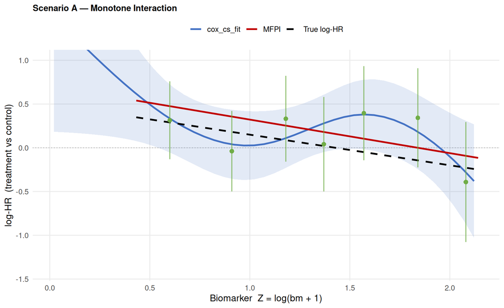

```r
plot_scenario(sim_res$monotone, "Scenario A — Monotone Interaction")
```

### 3.5 Scenario B — Threshold Interaction

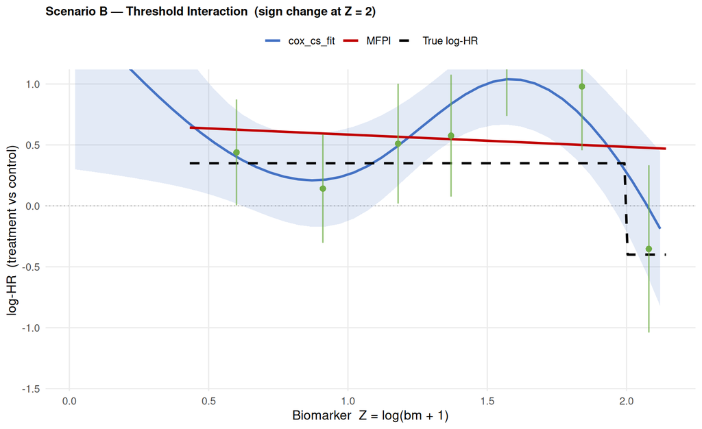

```r
plot_scenario(sim_res$threshold,
              "Scenario B — Threshold Interaction  (sign change at Z = 2)")
```

### 3.6 Scenario C — Null Interaction

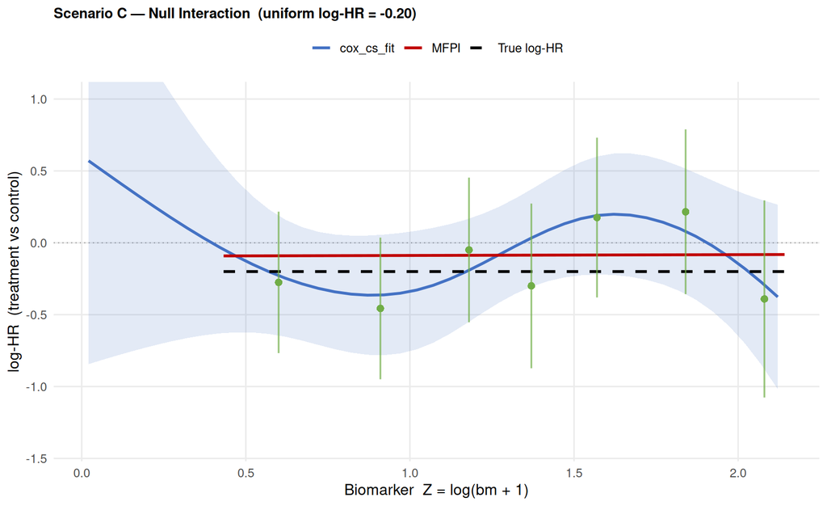

Scenario C: No interaction — uniform log-HR = -0.20. All methods should return approximately flat profiles. Residual curvature reflects sampling noise.

```r
plot_scenario(sim_res$null,
              "Scenario C — Null Interaction  (uniform log-HR = -0.20)")
```

### 3.7 Scenario D — Non-Monotone (Inverted-U) Interaction

The true log-HR is $-0.40(Z - 1.8)^2 + 0.50$: treatment is harmful near the gamma-distribution mode ($Z \approx 1.8$, pgr $\approx$ 5 fmol) and beneficial at both extremes. The sign reverses at $Z \approx 0.68$ and $Z \approx 2.92$.

This scenario is the most demanding:

- **`cox_cs_fit`** needs `spline_df` $\geq 3$ to represent the curvature; the CI band widens at both tails where data are sparse.
- **MFPI** must select a two-term FP or a degree-2 term ($Z^2$) to approximate the inverted-U; a linear FP will systematically bias toward the overall treatment effect.
- **STEPP** detects the pattern non-parametrically, but boundary windows may be noisy and windows spanning the peak may average harm and benefit.

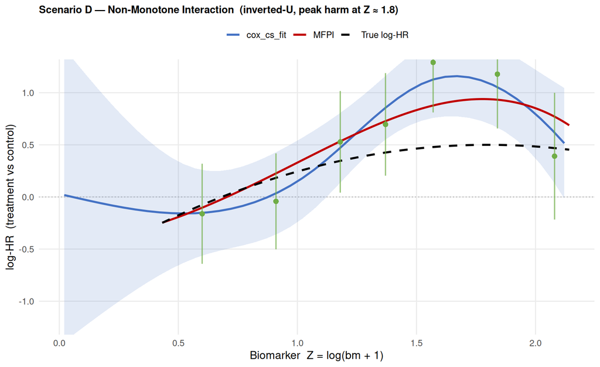

Scenario D: Non-monotone (inverted-U) interaction. Harm peaks near Z = 1.8 with benefit at both extremes. The spline is flexible enough with df = 3; MFPI requires a degree-2 FP to avoid underestimating the curvature.

```r
plot_scenario(sim_res$nonmonotone,
              "Scenario D — Non-Monotone Interaction  (inverted-U, peak harm at Z ≈ 1.8)",
              ylim = c(-1.2, 1.2))
```

### 3.8 Point Estimates at the Biomarker Median

```r
summarise_at_z <- function(res, scenario, z_eval = 1.2) {
  sc_key <- trimws(sub("^[A-Z]:\\s*", "", scenario))

  true_val <- switch(sc_key,
    Monotone    = , monotone    = 0.5 - 0.35 * z_eval,
    Threshold   = , threshold   = ifelse(z_eval < 2.0, 0.35, -0.40),
    Null        = , null        = -0.20,
    `Non-Monotone` = , nonmonotone = -0.40 * (z_eval - 1.8)^2 + 0.50,
    stop("Unknown scenario key: ", sc_key)
  )

  cc_idx <- which.min(abs(res$ccsf$z       - z_eval))
  mf_idx <- which.min(abs(res$mfpi$z       - z_eval))
  st_idx <- which.min(abs(res$stepp$mid_bm - z_eval))

  data.frame(
    Scenario              = scenario,
    `True log-HR`         = round(true_val, 3),
    `cox_cs_fit Est.`     = round(res$ccsf$loghr[cc_idx], 3),
    `cox_cs_fit CI Wid.`  = round(res$ccsf$hi[cc_idx] - res$ccsf$lo[cc_idx], 3),
    `MFPI Est.`           = round(res$mfpi$loghr[mf_idx], 3),
    `STEPP Est.`          = round(res$stepp$loghr[st_idx], 3),
    `STEPP CI Wid.`       = round(res$stepp$hi[st_idx] - res$stepp$lo[st_idx], 3),
    check.names           = FALSE
  )
}

knitr::kable(
  bind_rows(
    summarise_at_z(sim_res$monotone,    "A: Monotone"),
    summarise_at_z(sim_res$threshold,   "B: Threshold"),
    summarise_at_z(sim_res$null,        "C: Null"),
    summarise_at_z(sim_res$nonmonotone, "D: Non-Monotone")
  ),
  align = "lrrrrrrr"
)
```

Estimated log-HR at biomarker median (Z ≈ 1.2) for each scenario. cox_cs_fit CI width uses delta-method 95% interval; STEPP CI width uses 95% Wald CI per window.

| Scenario | True log-HR | cox_cs_fit Est. | cox_cs_fit CI Wid. | MFPI Est. | STEPP Est. | STEPP CI Wid. |
| --- | --- | --- | --- | --- | --- | --- |
| A: Monotone | 0.080 | 0.145 | 0.656 | 0.245 | 0.332 | 0.981 |
| B: Threshold | 0.350 | 0.567 | 0.625 | 0.564 | 0.510 | 0.983 |
| C: Null | -0.200 | -0.144 | 0.690 | -0.087 | -0.050 | 1.007 |
| D: Non-Monotone | 0.356 | 0.556 | 0.640 | 0.557 | 0.529 | 0.974 |

```r
# Short-name aliases used throughout — edit sim_* constants in the setup chunk
z_eval     <- sim_z_eval
B_eval     <- sim_B_eval
B_perm     <- sim_B_perm
alpha_eval <- sim_alpha
```

## 4 Joint Simulation Evaluation: `cox_cs_fit()` and STEPP

### 4.1 Design Rationale

**NoteWhy a joint simulation call?**

Running `cox_cs_fit()` and STEPP in **separate** parallel loops has two costs:

1. **Double worker overhead.** `plan(multisession)` is set up twice; each iteration generates the dataset twice — even though identical seeds produce identical data.
2. **Inexact comparison.** Even with the same seed sequence, OS scheduling means workers consume seeds in a non-deterministic order across two separate `foreach` calls. The datasets compared are only *stochastically* matched, not *exactly* matched iteration-by-iteration.

`run_joint_eval()` solves both problems: one `foreach` loop, one dataset per worker, both methods fit on the same draw. Benchmark overhead savings are largest when $B$ is large and per-fit time is short (STEPP is faster than the spline, so the joint approach roughly halves total wall time).

A shared `compute_sim_summary()` helper eliminates code duplication and ensures both methods are evaluated with identical metric definitions.

### 4.2 Simulation Metrics

Across $B =$ 5000 simulated trials at the fixed grid `z_eval`:

| Quantity | Definition | Target |
| --- | --- | --- |
| **Bias** | $\bar{\hat\beta}(z) - \beta_0(z)$ | 0 |
| **Relative bias** | $[\bar{\hat\beta}(z) - \beta_0(z)]\;/\;\|\beta_0(z)\|$ | 0; `NA` when $\|\beta_0(z)\| < 0.05$ |
| **Empirical SE** | $\text{SD}_{b=1}^B\{\hat\beta_b(z)\}$ | — |
| **Mean estimated SE** | $B^{-1}\sum_b \widehat{\text{SE}}_b(z)$ | — |
| **SE ratio** | Mean estimated SE / Empirical SE | 1.0 |
| **Coverage** | Proportion of 95% CIs containing the true log-HR | 0.95 |
| **Mean CI width** | $B^{-1}\sum_b (\hat\beta_{Ub}(z) - \hat\beta_{Lb}(z))$ | — |

SE ratio $\approx 1.0$ means the delta-method (spline) or Wald (STEPP) variance is well-calibrated. Coverage below 95% despite a good SE ratio signals **bias** from model misspecification — Scenarios B and D test this. Relative bias near zero-crossings of $\beta_0(z)$ is undefined and suppressed.

### 4.3 Simulation Engine

```r
# ── Shared metric computation ────────────────────────────────────────────────
compute_sim_summary <- function(mat_est, mat_se, mat_lo, mat_hi,
                                true_fn, z_eval, scenario) {
  mean_est <- colMeans(mat_est, na.rm = TRUE)
  bias_abs <- mean_est - true_fn
  # Relative bias: suppress when |truth| < 0.05 to avoid instability at
  # near-zero crossings (e.g. Scenario D near Z = 0.68 and Z = 2.92)
  rel_bias <- ifelse(abs(true_fn) >= 0.05, bias_abs / abs(true_fn), NA_real_)

  emp_se   <- apply(mat_est, 2, sd,     na.rm = TRUE)
  mean_se  <- colMeans(mat_se,          na.rm = TRUE)
  ci_width <- colMeans(mat_hi - mat_lo, na.rm = TRUE)
  covered  <- sweep(mat_lo, 2, true_fn, "<=") & sweep(mat_hi, 2, true_fn, ">=")

  data.frame(
    z          = z_eval,
    true_loghr = round(true_fn,  3),
    n_valid    = colSums(!is.na(mat_est)),
    bias       = round(bias_abs, 3),
    rel_bias   = round(rel_bias, 3),
    mean_est   = round(mean_est, 3),
    emp_se     = round(emp_se,   3),
    mean_se    = round(mean_se,  3),
    se_ratio   = round(mean_se / emp_se, 3),
    coverage   = round(colMeans(covered, na.rm = TRUE), 3),
    ci_width   = round(ci_width, 3),
    scenario   = scenario,
    stringsAsFactors = FALSE
  )
}

# ── Joint evaluation engine ──────────────────────────────────────────────────
run_joint_eval <- function(scenario,
                           B          = sim_B_eval,
                           z_eval     = sim_z_eval,
                           alpha      = sim_alpha,
                           patspop    = sim_patspop,
                           minpatspop = sim_minpatspop,
                           n_workers  = sim_n_workers) {
  n_z <- length(z_eval)

  old_plan <- plan()
  on.exit(plan(old_plan), add = TRUE)
  plan(multisession, workers = n_workers)

  message(sprintf(
    "run_joint_eval [%s]: B = %d | workers = %d | r2 = %d, r1 = %d",
    scenario, B, n_workers, patspop, minpatspop
  ))

  t_sc <- proc.time()

  res_list <- foreach(
    b               = seq_len(B),
    .combine        = "c",
    .options.future = list(seed = TRUE)
  ) %dofuture% {
    set.seed(b)
    library(forestsearch)
    library(survival)
    library(splines)

    # ── Single dataset draw shared by both methods ──────────────────────────
    d          <- simulate_trial(scenario = scenario, seed = b)
    d$os_time  <- d$tte
    d$os_event <- d$event

    na_out <- list(est = rep(NA_real_, n_z), se = rep(NA_real_, n_z),
                   lo  = rep(NA_real_, n_z), hi = rep(NA_real_, n_z))

    # ── cox_cs_fit ──────────────────────────────────────────────────────────
    fit_cc <- tryCatch(
      cox_cs_fit(
        df         = d,
        tte_name   = "os_time",
        event_name = "os_event",
        treat_name = "treat",
        z_name     = "Z",
        spline_df  = sim_spline_df,
        z_by       = 0.05,
        z_quantile = 0.95,
        alpha      = alpha,
        show_plot  = FALSE,
        verbose    = FALSE
      ),
      error = function(e) NULL
    )

    out_cc <- na_out
    if (!is.null(fit_cc)) {
      ok <- z_eval >= min(fit_cc$z_profile) & z_eval <= max(fit_cc$z_profile)
      if (any(ok)) {
        out_cc$est[ok] <- approx(fit_cc$z_profile, fit_cc$loghr_est,   xout = z_eval[ok])$y
        out_cc$se [ok] <- approx(fit_cc$z_profile, fit_cc$se_loghr,    xout = z_eval[ok])$y
        out_cc$lo [ok] <- approx(fit_cc$z_profile, fit_cc$loghr_lower, xout = z_eval[ok])$y
        out_cc$hi [ok] <- approx(fit_cc$z_profile, fit_cc$loghr_upper, xout = z_eval[ok])$y
      }
    }

    # ── STEPP (Cox fallback) ────────────────────────────────────────────────
    fit_st <- tryCatch(
      stepp_windows(
        df         = d,
        bm_var     = "Z",
        tte_var    = "tte",
        event_var  = "event",
        treat_var  = "treat",
        patspop    = sim_patspop,
        minpatspop = sim_minpatspop,
        conf_level = 1 - sim_alpha
      ),
      error = function(e) NULL
    )

    out_st <- na_out
    if (!is.null(fit_st) && nrow(fit_st) >= 2L) {
      ok <- z_eval >= min(fit_st$mid_bm) & z_eval <= max(fit_st$mid_bm)
      if (any(ok)) {
        out_st$est[ok] <- approx(fit_st$mid_bm, fit_st$loghr,    xout = z_eval[ok])$y
        out_st$se [ok] <- approx(fit_st$mid_bm, fit_st$se_loghr, xout = z_eval[ok])$y
        out_st$lo [ok] <- approx(fit_st$mid_bm, fit_st$lo,       xout = z_eval[ok])$y
        out_st$hi [ok] <- approx(fit_st$mid_bm, fit_st$hi,       xout = z_eval[ok])$y
      }
    }

    list(list(cc = out_cc, st = out_st))
  }

  elapsed_sec <- round((proc.time() - t_sc)["elapsed"])

  # ── Assemble result matrices ────────────────────────────────────────────────
  mat_cc_est <- do.call(rbind, lapply(res_list, function(x) x$cc$est))
  mat_cc_se  <- do.call(rbind, lapply(res_list, function(x) x$cc$se))
  mat_cc_lo  <- do.call(rbind, lapply(res_list, function(x) x$cc$lo))
  mat_cc_hi  <- do.call(rbind, lapply(res_list, function(x) x$cc$hi))

  mat_st_est <- do.call(rbind, lapply(res_list, function(x) x$st$est))
  mat_st_se  <- do.call(rbind, lapply(res_list, function(x) x$st$se))
  mat_st_lo  <- do.call(rbind, lapply(res_list, function(x) x$st$lo))
  mat_st_hi  <- do.call(rbind, lapply(res_list, function(x) x$st$hi))

  true_fn <- switch(scenario,
    monotone    = 0.5 - 0.35 * z_eval,
    threshold   = ifelse(z_eval < 2.0, 0.35, -0.40),
    null        = rep(-0.20, n_z),
    nonmonotone = -0.40 * (z_eval - 1.8)^2 + 0.50,
    stop("Unknown scenario: ", scenario)
  )

  ccsf_sum  <- compute_sim_summary(mat_cc_est, mat_cc_se, mat_cc_lo, mat_cc_hi,
                                   true_fn, z_eval, scenario)
  stepp_sum <- compute_sim_summary(mat_st_est, mat_st_se, mat_st_lo, mat_st_hi,
                                   true_fn, z_eval, scenario)

  list(
    ccsf  = list(summary = ccsf_sum,
                 mat_est = mat_cc_est, mat_se = mat_cc_se,
                 mat_lo  = mat_cc_lo,  mat_hi = mat_cc_hi,
                 true_fn = true_fn),
    stepp = list(summary = stepp_sum,
                 mat_est = mat_st_est, mat_se = mat_st_se,
                 mat_lo  = mat_st_lo,  mat_hi = mat_st_hi,
                 true_fn = true_fn),
    elapsed_sec = elapsed_sec,
    scenario    = scenario,
    B           = B
  )
}
```

### 4.4 Run Evaluation — All Four Scenarios

```r
t_joint_start <- proc.time()

eval_joint_monotone    <- run_joint_eval("monotone",    B = B_eval, z_eval = z_eval,
                                         alpha = alpha_eval, patspop = sim_patspop,
                                         minpatspop = sim_minpatspop, n_workers = sim_n_workers)
eval_joint_threshold   <- run_joint_eval("threshold",   B = B_eval, z_eval = z_eval,
                                         alpha = alpha_eval, patspop = sim_patspop,
                                         minpatspop = sim_minpatspop, n_workers = sim_n_workers)
eval_joint_null        <- run_joint_eval("null",        B = B_eval, z_eval = z_eval,
                                         alpha = alpha_eval, patspop = sim_patspop,
                                         minpatspop = sim_minpatspop, n_workers = sim_n_workers)
eval_joint_nonmonotone <- run_joint_eval("nonmonotone", B = B_eval, z_eval = z_eval,
                                         alpha = alpha_eval, patspop = sim_patspop,
                                         minpatspop = sim_minpatspop, n_workers = sim_n_workers)

t_joint_total <- round((proc.time() - t_joint_start)["elapsed"])
cat(sprintf("Joint evaluation complete: B = %d | %d scenarios | total elapsed: %d sec\n",
            B_eval, 4L, t_joint_total))
```

```
Joint evaluation complete: B = 5000 | 4 scenarios | total elapsed: 43 sec
```

```r
# ── Backward-compatible aliases (downstream chunks unchanged) ────────────────
eval_ccsf_monotone    <- eval_joint_monotone$ccsf
eval_ccsf_threshold   <- eval_joint_threshold$ccsf
eval_ccsf_null        <- eval_joint_null$ccsf
eval_ccsf_nonmonotone <- eval_joint_nonmonotone$ccsf

eval_stepp_monotone    <- eval_joint_monotone$stepp
eval_stepp_threshold   <- eval_joint_threshold$stepp
eval_stepp_null        <- eval_joint_null$stepp
eval_stepp_nonmonotone <- eval_joint_nonmonotone$stepp
```

### 4.5 Simulation Timing

```r
timing_df <- data.frame(
  Scenario    = c("A: Monotone", "B: Threshold", "C: Null", "D: Non-Monotone"),
  `Elapsed (sec)` = c(
    eval_joint_monotone$elapsed_sec,
    eval_joint_threshold$elapsed_sec,
    eval_joint_null$elapsed_sec,
    eval_joint_nonmonotone$elapsed_sec
  ),
  `B` = B_eval,
  `sec / sim` = round(c(
    eval_joint_monotone$elapsed_sec,
    eval_joint_threshold$elapsed_sec,
    eval_joint_null$elapsed_sec,
    eval_joint_nonmonotone$elapsed_sec
  ) / B_eval, 4),
  check.names = FALSE
)
timing_df <- rbind(
  timing_df,
  data.frame(Scenario = "**Total**",
             `Elapsed (sec)` = t_joint_total,
             `B` = 4L * B_eval,
             `sec / sim` = round(t_joint_total / (4L * B_eval), 4),
             check.names = FALSE)
)
knitr::kable(timing_df, align = "lrrr")
```

Wall-clock time (seconds) per scenario. Each scenario fits both cox_cs_fit() and STEPP on the same B simulated datasets in a single parallel loop.

|  | Scenario | Elapsed (sec) | B | sec / sim |
| --- | --- | --- | --- | --- |
| 1 | A: Monotone | 8 | 5000 | 0.0016 |
| 2 | B: Threshold | 8 | 5000 | 0.0016 |
| 3 | C: Null | 8 | 5000 | 0.0016 |
| 4 | D: Non-Monotone | 8 | 5000 | 0.0016 |
| elapsed | **Total** | 43 | 20000 | 0.0022 |

### 4.6 `cox_cs_fit()` Results Table

```r
all_ccsf <- bind_rows(
  eval_ccsf_monotone$summary,
  eval_ccsf_threshold$summary,
  eval_ccsf_null$summary,
  eval_ccsf_nonmonotone$summary
) |>
  mutate(Scenario = case_match(scenario,
    "monotone"    ~ "A: Monotone",
    "threshold"   ~ "B: Threshold",
    "null"        ~ "C: Null",
    "nonmonotone" ~ "D: Non-Monotone"
  )) |>
  select(Scenario, z, true_loghr, mean_est, bias, rel_bias,
         emp_se, mean_se, se_ratio, coverage, ci_width)

knitr::kable(all_ccsf,
             col.names = c("Scenario", "z", "log-HR", "Est", "Bias", "Rel Bias",
                           "Emp SE", "Mean SE", "SE Ratio", "Coverage", "CI Wid"),
             align = "lrrrrrrrrrrr", digits = 3)
```

cox_cs_fit() SE and coverage across B = 5000 simulations. SE ratio target = 1.0; coverage target = 0.95.

| Scenario | z | log-HR | Est | Bias | Rel Bias | Emp SE | Mean SE | SE Ratio | Coverage | CI Wid |
| --- | --- | --- | --- | --- | --- | --- | --- | --- | --- | --- |
| A: Monotone | 0.6 | 0.290 | 0.444 | 0.154 | 0.529 | 0.220 | 0.216 | 0.979 | 0.894 | 0.845 |
| A: Monotone | 0.8 | 0.220 | 0.334 | 0.114 | 0.516 | 0.196 | 0.195 | 0.994 | 0.912 | 0.765 |
| A: Monotone | 1.0 | 0.150 | 0.226 | 0.076 | 0.505 | 0.200 | 0.199 | 0.998 | 0.931 | 0.782 |
| A: Monotone | 1.2 | 0.080 | 0.120 | 0.040 | 0.505 | 0.173 | 0.174 | 1.001 | 0.945 | 0.681 |
| A: Monotone | 1.4 | 0.010 | 0.017 | 0.007 | NA | 0.175 | 0.174 | 0.996 | 0.949 | 0.684 |
| A: Monotone | 1.6 | -0.060 | -0.088 | -0.028 | -0.473 | 0.217 | 0.214 | 0.985 | 0.945 | 0.839 |
| A: Monotone | 1.8 | -0.130 | -0.197 | -0.067 | -0.515 | 0.233 | 0.227 | 0.977 | 0.937 | 0.891 |
| A: Monotone | 2.0 | -0.200 | -0.309 | -0.109 | -0.543 | 0.275 | 0.267 | 0.971 | 0.934 | 1.046 |
| B: Threshold | 0.6 | 0.350 | 0.514 | 0.164 | 0.470 | 0.218 | 0.214 | 0.980 | 0.882 | 0.837 |
| B: Threshold | 0.8 | 0.350 | 0.497 | 0.147 | 0.419 | 0.192 | 0.190 | 0.992 | 0.881 | 0.745 |
| B: Threshold | 1.0 | 0.350 | 0.506 | 0.156 | 0.447 | 0.194 | 0.193 | 0.993 | 0.874 | 0.756 |
| B: Threshold | 1.2 | 0.350 | 0.549 | 0.199 | 0.567 | 0.166 | 0.166 | 0.996 | 0.777 | 0.650 |
| B: Threshold | 1.4 | 0.350 | 0.587 | 0.237 | 0.677 | 0.163 | 0.162 | 0.998 | 0.694 | 0.636 |
| B: Threshold | 1.6 | 0.350 | 0.548 | 0.198 | 0.565 | 0.200 | 0.198 | 0.990 | 0.831 | 0.774 |
| B: Threshold | 1.8 | 0.350 | 0.381 | 0.031 | 0.087 | 0.213 | 0.209 | 0.984 | 0.944 | 0.820 |
| B: Threshold | 2.0 | -0.400 | 0.097 | 0.497 | 1.243 | 0.262 | 0.255 | 0.974 | 0.497 | 0.999 |
| C: Null | 0.6 | -0.200 | -0.304 | -0.104 | -0.519 | 0.248 | 0.243 | 0.977 | 0.929 | 0.951 |
| C: Null | 0.8 | -0.200 | -0.302 | -0.102 | -0.509 | 0.217 | 0.214 | 0.989 | 0.926 | 0.840 |
| C: Null | 1.0 | -0.200 | -0.300 | -0.100 | -0.501 | 0.219 | 0.219 | 0.996 | 0.932 | 0.857 |
| C: Null | 1.2 | -0.200 | -0.299 | -0.099 | -0.497 | 0.189 | 0.189 | 1.001 | 0.920 | 0.742 |
| C: Null | 1.4 | -0.200 | -0.299 | -0.099 | -0.497 | 0.184 | 0.183 | 0.995 | 0.914 | 0.718 |
| C: Null | 1.6 | -0.200 | -0.301 | -0.101 | -0.505 | 0.226 | 0.222 | 0.982 | 0.922 | 0.871 |
| C: Null | 1.8 | -0.200 | -0.304 | -0.104 | -0.521 | 0.241 | 0.235 | 0.975 | 0.927 | 0.922 |
| C: Null | 2.0 | -0.200 | -0.309 | -0.109 | -0.544 | 0.274 | 0.265 | 0.970 | 0.929 | 1.040 |
| D: Non-Monotone | 0.6 | -0.076 | -0.132 | -0.056 | -0.740 | 0.245 | 0.241 | 0.982 | 0.941 | 0.943 |
| D: Non-Monotone | 0.8 | 0.100 | 0.138 | 0.038 | 0.375 | 0.197 | 0.196 | 0.996 | 0.947 | 0.769 |
| D: Non-Monotone | 1.0 | 0.244 | 0.367 | 0.123 | 0.503 | 0.198 | 0.196 | 0.992 | 0.906 | 0.769 |
| D: Non-Monotone | 1.2 | 0.356 | 0.544 | 0.188 | 0.529 | 0.171 | 0.170 | 0.990 | 0.806 | 0.665 |
| D: Non-Monotone | 1.4 | 0.436 | 0.666 | 0.230 | 0.527 | 0.158 | 0.158 | 0.998 | 0.701 | 0.620 |
| D: Non-Monotone | 1.6 | 0.484 | 0.733 | 0.249 | 0.515 | 0.191 | 0.190 | 0.996 | 0.745 | 0.744 |
| D: Non-Monotone | 1.8 | 0.500 | 0.749 | 0.249 | 0.498 | 0.203 | 0.201 | 0.992 | 0.772 | 0.788 |
| D: Non-Monotone | 2.0 | 0.484 | 0.722 | 0.238 | 0.492 | 0.227 | 0.225 | 0.990 | 0.822 | 0.880 |